# Impacts of Storm Events on Population Health and Economics in the United States from 1950-2011

Jessica

12/3/2020

## Synopsis

The U.S. National Oceanic and Atmospheric Administration’s (NOAA) Storm Database, documents:

- The occurrence of storms and other significant weather phenomena having sufficient intensity to cause loss of life, injuries, significant property damage, and/or disruption to commerce;
- Rare, unusual, weather phenomena that generate media attention, such as snow flurries in South Florida or the San Diego coastal area; and
- Other significant meteorological events, such as record maximum or minimum temperatures or precipitation that occur in connection with another event.

In this report, we aim to answer the following questions:

1. Across the United States, which types of weather events are most harmful with respect to population health?
2. Across the United States, which types of weather events have the greatest economic consequences?

**Summary: the Health Impacts of Severe Weather Events**

From these data, we found that, ‘tornado’ is the weather event that has killed and injured the most people in the US and outlying areas between 1950 and 2011. Tornadoes have killed 5,633 people and injured 91,346 people.

There are regional differences across the US. We found that while tornadoes have a large impact on the overall number of fatalities across the US, they do not impact all regions homogeneously. Tornadoes have the largest impact on people living in the regions of the South, Central, and Southeast United States while the Northeast and West loose more people to Excessive Heat events.

**Summary: the Economic Impacts of Severe Weather Events**

## Population Health

### Data Processing

#### Load libraries

```r
library(tidyverse)
library(readr)
library(dplyr)
library(scales)
library(viridis)
library(hrbrthemes)
```

#### Load data & clean

- Load the raw data, download from the internet if it has not been downloaded
- Check “EVTYPE” to ensure there are no leading spaces or other inconsistencies
- Format the dates
- Add a ‘year’ variable

```r
# 1. Load the data
file_url <- "https://d396qusza40orc.cloudfront.net/repdata%2Fdata%2FStormData.csv.bz2"
if(!file.exists("./data/reproducible_research_project_2.bz2")){
  download.file(file_url, destfile = "./data/reproducible_research_project_2.csv.bz2", method = "curl")
}

# 2. Read data into global environment
if(!exists("storm_data")) {
  storm_data <- read.table("data/reproducible_research_project_2.csv.bz2", header = TRUE, sep = ",", dec = ".")
}

# 3. Check the dimensions of the data
dim(storm_data)
```

```
## [1] 902297     37
```

```r
# 4. Check "event type" to get a sense for what types of events are in the dataset
  # Ensure that all the event types are upper case & extra spaces are removed
  storm_data$EVTYPE <- toupper(storm_data$EVTYPE)
  storm_data$EVTYPE <- trimws(storm_data$EVTYPE, which = c("both"))
  unique_states <- unique(storm_data$STATE)
  unique_events <- unique(storm_data$EVTYPE)
  NROW(unique_events)
```

```
## [1] 890
```

```r
# 5. Add a 'year' variable
storm_data$begin_date <- as.Date(storm_data$BGN_DATE,"%m/%d/%Y")
storm_data$year <- as.numeric(format(storm_data$begin_date,"%Y"))

# 6. Processing for health variables
health_vars <- c('FATALITIES', 'INJURIES')
```

### Variables of interest: Health

For the population health portion of this analysis, we’ll be looking at fatalities and injuries by storm type. Our variables of interest include:

- EVTYPE: Type of weather event, i.e. “Avalanche”, “High Wind”
- FATALITIES: Fatalities due to specific weather event
- INJURIES: Injuries due to specific weather event

### Results: Fatalities and injuries

1. Look at the ten weather events that caused the most fatalities in all states and areas.

```r
fatalities <- aggregate(FATALITIES ~ EVTYPE, data = storm_data, sum)
fatalities <- arrange(fatalities, desc(FATALITIES))
fatalities_ten <- head(fatalities, n=10)
highest_death <- fatalities_ten[1,2]
fatalities_ten
```

```
##            EVTYPE FATALITIES
## 1         TORNADO       5633
## 2  EXCESSIVE HEAT       1903
## 3     FLASH FLOOD        978
## 4            HEAT        937
## 5       LIGHTNING        816
## 6       TSTM WIND        504
## 7           FLOOD        470
## 8     RIP CURRENT        368
## 9       HIGH WIND        248
## 10      AVALANCHE        224
```

2. Look at the ten weather events that caused the most injuries in all states and areas.

```r
injuries <- aggregate(INJURIES ~ EVTYPE, data = storm_data, sum)
injuries <- arrange(injuries, desc(INJURIES))
injuries_ten <- head(injuries, n=10)
highest_injury <- injuries_ten[1,2]
injuries_ten
```

```
##               EVTYPE INJURIES
## 1            TORNADO    91346
## 2          TSTM WIND     6957
## 3              FLOOD     6789
## 4     EXCESSIVE HEAT     6525
## 5          LIGHTNING     5230
## 6               HEAT     2100
## 7          ICE STORM     1975
## 8        FLASH FLOOD     1777
## 9  THUNDERSTORM WIND     1488
## 10              HAIL     1361
```

#### Fatalities and injuries by event

3. Create a barplot showing the number of fatalities and injuries by event

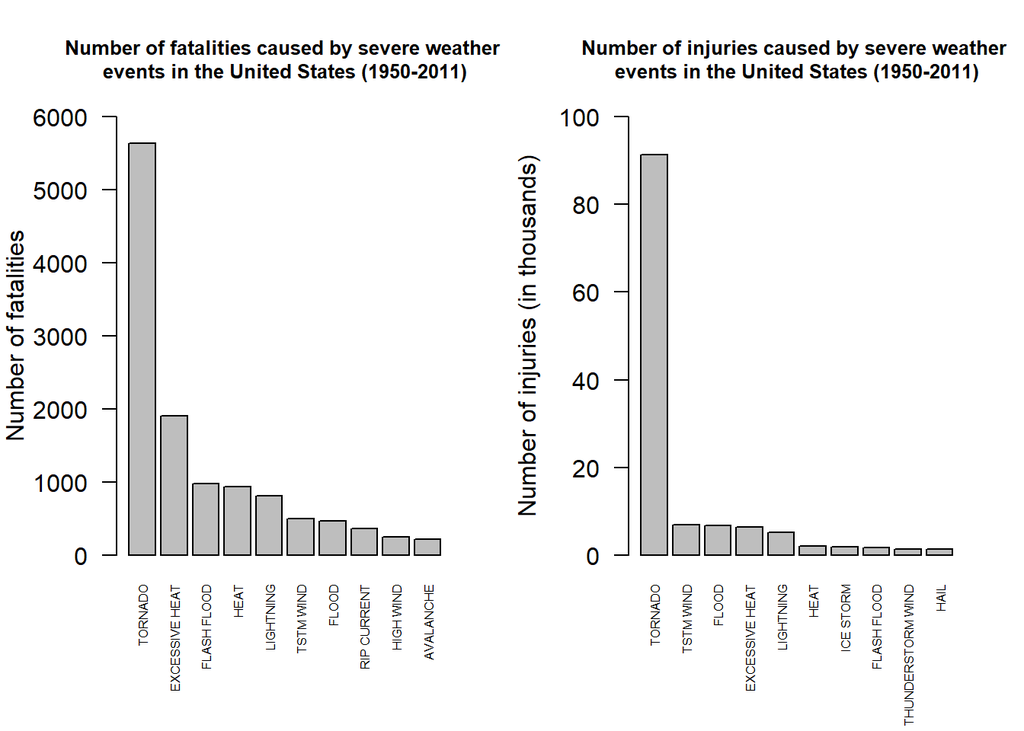

```r
par(mar = c(6, 4, 4, 2), mfrow = c(1, 2))

barplot(fatalities_ten$FATALITIES,
        ylim = c(0, 6000),
        names.arg = fatalities_ten$EVTYPE,
        cex.names = 0.5,
        cex.main = 0.8,
        las = 2,
        main = "Number of fatalities caused by severe weather \nevents in the United States (1950-2011)",
        ylab = "Number of fatalities"
        )

barplot(injuries_ten$INJURIES/1000,
        ylim = c(0, 100),
        names.arg = injuries_ten$EVTYPE,
        cex.names = 0.5,
        cex.main = 0.8,
        las = 2,
        main = "Number of injuries caused by severe weather \nevents in the United States (1950-2011)",
        ylab = "Number of injuries (in thousands)"
        )
```

#### Fatalities and injuries by event and region

4. Look at regional differences in fatalities and injuries.

```r
# 1. Add a 'region' variable to look at regional differences (regions from NOAA website, Wikipedia, & grouping remaining unmatched regions with associated states based on the variable COUNTYNAME. There are 72 "states", "us territories", and "regions" in this data frame.)

regions <- data.frame(region = "Central", state = c("IL", "IN", "KY",   "MO",   "OH",   "TN",   "WV", "LE"))
east_n_central <- (data.frame(region = "East North Central", state = c("IA",    "MI",   "MN",   "WI", "LC", "LH", "LM", "LS")))
northeast <- (data.frame(region = "Northeast", state = c("CT",  "DE",   "ME",   "MD",   "MA",   "NH",   "NJ",   "NY",   "PA",   "RI",   "VT", "AN", "SL", "LO", "XX")))
northwest <- (data.frame(region = "Northwest", state =c("ID",   "OR",   "WA", "AK", "PK")))
south <- (data.frame(region = "South", state =c("AR",   "KS",   "LA",   "MS",   "OK",   "TX")))
southeast <- (data.frame(region = "Southeast", state =c("AL",   "FL",   "GA",   "NC",   "SC",   "VA", "DC", "AM", "GM")))
southwest <- (data.frame(region = "Southwest", state =c("AZ",   "CO",   "NM",   "UT")))
west <- (data.frame(region = "West", state =c("CA", "NV")))
west_n_central <- (data.frame(region = "West North Central", state =c("MT", "NE",   "ND",   "SD",   "WY")))
islands <- (data.frame(region = "Islands", state =c("HI", "PR", "AS", "GU", "MH", "VI", "PH", "PZ", "PM")))

regions <- rbind(regions, east_n_central, northeast, northwest, south, southeast, southwest, west, west_n_central, islands)

# 2. Make sure all of the states are classified into a region
states_regions <- regions$state
unique_states <- unique(storm_data$STATE)
common_states <-  intersect(unique_states, states_regions)
unmatched_states <- unique_states [! unique_states %in% common_states]

# 3. Make region table to include the numbers of the states with a merge on state
state_numbers <- data.frame(storm_data[, c("STATE", "STATE__")])

state_numbers <- distinct(state_numbers, STATE, .keep_all = TRUE)

regions <- regions %>%
  rename(
    STATE = state
  )

regions <- merge(regions, state_numbers)

# 4. Set duplicate state number 20 to NA (this is one value, that looks to be incorrectly coded as "ST")
bad_state_index = match("ST", storm_data$STATE)
storm_data$STATE__[bad_state_index] <- NA

# 5. Build vector of regions at index
build_region_lookup <- function(regions) {
  max_state_id <- max(regions$STATE__)
  my_lookup_vector <- vector(mode="character", length=max_state_id)
  for (i in 1:nrow(regions)) {
    state_id <- regions$STATE__[i]
    if (!is.na(state_id)) {
      my_lookup_vector[state_id] <- regions$region[i]
    }
  }
  return (my_lookup_vector)
}

# 6. Assign region to each row of the storm dataframe based on STATE__
state_id_to_region <- build_region_lookup(regions)
storm_data$region <-state_id_to_region[storm_data$STATE__]

# 7. Look at fatalities by region
regional_fatalities <- aggregate(FATALITIES ~ region, data = storm_data, sum)
regional_fatalities <- arrange(regional_fatalities, desc(FATALITIES))
regional_fatalities <- head(regional_fatalities, n=10)
```

5. Return the weather event that produces the most fatalities within each region and the number of fatalities

```r
##
regional_fatalities_top <- data.frame(region = character(), EVTYPE = character(), FATALITIES = double())

unique_regions <- unique(regions$region)

for(r in unique_regions) {
  central_df <- filter(storm_data, region == r)
  central_df <- aggregate(FATALITIES ~ EVTYPE, data = central_df, sum)
  central_df <- arrange(central_df, desc(FATALITIES))
  new_row <- c(r, central_df$EVTYPE[1], central_df$FATALITIES[1])
  regional_fatalities_top <- rbind(regional_fatalities_top, new_row)
  names(new_row) <- c("region", "EVTYPE", "FATALITIES")
}

regional_fatalities_top <- regional_fatalities_top %>%
  rename(
    Region = X.Northwest.,
    Event = X.AVALANCHE.,
    Fatalities = X.87.
  )

regional_fatalities_top$Fatalities <- as.numeric(regional_fatalities_top$Fatalities)
regional_fatalities_top <- arrange(regional_fatalities_top, desc(Fatalities))
regional_fatalities_top
```

```
##                Region          Event Fatalities
## 1               South        TORNADO       2052
## 2             Central        TORNADO       1530
## 3           Southeast        TORNADO       1179
## 4           Northeast EXCESSIVE HEAT        587
## 5  East North Central        TORNADO        519
## 6                West EXCESSIVE HEAT        123
## 7  West North Central        TORNADO        105
## 8           Southwest    FLASH FLOOD        101
## 9           Northwest      AVALANCHE         87
## 10            Islands    FLASH FLOOD         49
```

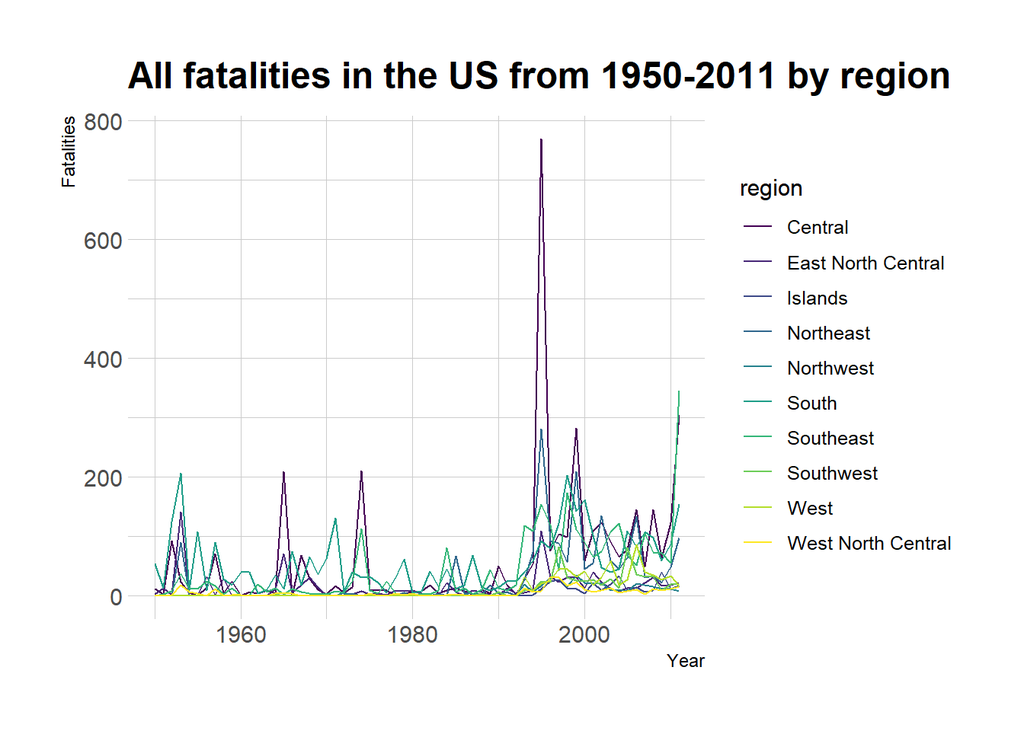

```r
# Look at fatalties by region over time
regional_fatalities_time <- aggregate(FATALITIES ~ year*region, data = storm_data, sum)
regional_fatalities_time$year <- as.numeric(regional_fatalities_time$year)

regional_fatalities_time %>%
  ggplot( aes(x=year, y=FATALITIES, group=region, color=region)) +
    geom_line() +
  scale_color_viridis(discrete = TRUE) +
  ggtitle("All fatalities in the US from 1950-2011 by region") +
  ylab("Fatalities") +
  xlab("Year") +
  theme_ipsum()
```

- In 1995, an intense heat wave affected northern Illinois from Wednesday July 12 through Sunday July 16. The heat wave tied or broke several temperature records at Rockford and Chicago. But what set this heat wave apart from others was the extremely high humidities. Dew point temperatures peaked in the lower 80s late Wednesday the 12th and Thursday the 13th and were generally in the middle and upper 70s through the rest of the hot spell. The combined and cumulative effects of several days of high temperatures, high humidity, intense July sunshine (100% possible sunshine recorded at O’Hare Airport in Chicago July 13) and light winds took their toll. 583 people died as a result of the heat in Chicago and surrounding areas.

## Economic Impacts

### Data Processing

I will examine the economic variables to understand how to utilize them in this analysis.

```r
econ_vars <- c('PROPDMG', 'PROPDMGEXP', 'CROPDMG', 'CROPDMGEXP')

head(storm_data %>% select(econ_vars))
```

```
## Note: Using an external vector in selections is ambiguous.
## i Use `all_of(econ_vars)` instead of `econ_vars` to silence this message.
## i See <https://tidyselect.r-lib.org/reference/faq-external-vector.html>.
```

```
##   PROPDMG PROPDMGEXP CROPDMG CROPDMGEXP
## 1    25.0          K       0
## 2     2.5          K       0
## 3    25.0          K       0
## 4     2.5          K       0
## 5     2.5          K       0
## 6     2.5          K       0
```

Based on details from the documentation on the variable ‘PROPDMGEXP’, the letters signify magnitude:

- “K” for thousands
- “M” for millions
- “B” for billions

Examine each variable:

1. PROPDMG

```r
summary(storm_data$PROPDMG)
```

```
##    Min. 1st Qu.  Median    Mean 3rd Qu.    Max.
##    0.00    0.00    0.00   12.06    0.50 5000.00
```

2. PROPDMGEXP

```r
print(unique(storm_data$PROPDMGEXP))
```

```
##  [1] "K" "M" ""  "B" "m" "+" "0" "5" "6" "?" "4" "2" "3" "h" "7" "H" "-" "1" "8"
```

- Make all of the values in PROPDMGEXP capital letters:

```r
storm_data$PROPDMGEXP <- toupper(storm_data$PROPDMGEXP)
print(unique(storm_data$PROPDMGEXP))
```

```
##  [1] "K" "M" ""  "B" "+" "0" "5" "6" "?" "4" "2" "3" "H" "7" "-" "1" "8"
```

- I would like to see how many rows each of these appears:

```r
exp_count = summarise(group_by(storm_data, PROPDMGEXP), count = n())
exp_count = arrange(exp_count, PROPDMGEXP)
exp_count
```

```
## # A tibble: 17 x 2
##    PROPDMGEXP  count
##    <chr>       <int>
##  1 ""         465934
##  2 "-"             1
##  3 "?"             8
##  4 "+"             5
##  5 "0"           216
##  6 "1"            25
##  7 "2"            13
##  8 "3"             4
##  9 "4"             4
## 10 "5"            28
## 11 "6"             4
## 12 "7"             5
## 13 "8"             1
## 14 "B"            40
## 15 "H"             7
## 16 "K"        424665
## 17 "M"         11337
```

- I cannot say with certainty that the numbers ‘0-8’ indicate the value that PROPDMG should be exponentiated. Therefore, those values will not be included in this analysis.
- Factor out the known exponetiators & then remove the exponentiators with a count of less than 40.

```r
exp_count$PROPDMGEXP <- as.factor(exp_count$PROPDMGEXP)

exp_keep <- levels(droplevels(exp_count$PROPDMGEXP[exp_count$count>39]))

econ_impacts <- storm_data %>%
              filter(PROPDMGEXP %in% exp_keep) %>%
              select(c("EVTYPE", econ_vars, year, region))
```

3. CROPDMG

```r
summary(storm_data$CROPDMG, useNA='always')
```

```
##    Min. 1st Qu.  Median    Mean 3rd Qu.    Max.
##   0.000   0.000   0.000   1.527   0.000 990.000
```

4. CROPDMGEXP

```r
storm_data$CROPDMGEXP <- toupper(storm_data$CROPDMGEXP)
print(unique(storm_data$CROPDMGEXP))
```

```
## [1] ""  "M" "K" "B" "?" "0" "2"
```

```r
exp_count_crop = summarise(group_by(storm_data, CROPDMGEXP), count = n())
exp_count_crop = arrange(exp_count_crop, CROPDMGEXP)
exp_count_crop
```

```
## # A tibble: 7 x 2
##   CROPDMGEXP  count
##   <chr>       <int>
## 1 ""         618413
## 2 "?"             7
## 3 "0"            19
## 4 "2"             1
## 5 "B"             9
## 6 "K"        281853
## 7 "M"          1995
```

- For CROPDMGEXP, I’m not sure how to interpret ‘0’, ‘?’, or ‘2’, so we will filter those out of the analysis dataframe

```r
exp_count_crop$CROPDMGEXP <- as.factor(exp_count_crop$CROPDMGEXP)

exp_keep_crop <- levels(droplevels(exp_count_crop$CROPDMGEXP[exp_count_crop$CROPDMGEXP == "" |
                                                               exp_count_crop$CROPDMGEXP == "B" |
                                                               exp_count_crop$CROPDMGEXP == "M" |
                                                               exp_count_crop$CROPDMGEXP == "K" |
                                                               exp_count_crop$CROPDMGEXP == "0"]))

econ_impacts <- econ_impacts %>%
              filter(CROPDMGEXP %in% exp_keep_crop) %>%
              select(c("EVTYPE", econ_vars, year, region))

head(econ_impacts)
```

```
##    EVTYPE PROPDMG PROPDMGEXP CROPDMG CROPDMGEXP year    region
## 1 TORNADO    25.0          K       0            1950 Southeast
## 2 TORNADO     2.5          K       0            1950 Southeast
## 3 TORNADO    25.0          K       0            1951 Southeast
## 4 TORNADO     2.5          K       0            1951 Southeast
## 5 TORNADO     2.5          K       0            1951 Southeast
## 6 TORNADO     2.5          K       0            1951 Southeast
```

- Multiply both PROPDMG & CROPDMG by exponentiators

```r
exp_map <- data.frame(letter = c("", "K", "M", "B"), mul_prop = c(1, 1000, 1000000, 1000000000))
econ_impacts <- inner_join(econ_impacts, exp_map, by=c("PROPDMGEXP" = "letter"))

exp_map_crop <- data.frame(letter = c("", "K", "M", "B"), mul_crop = c(1, 1000, 1000000, 1000000000))
econ_impacts <- inner_join(econ_impacts, exp_map_crop, by=c("CROPDMGEXP" = "letter"))

econ_impacts$property <- econ_impacts$PROPDMG * econ_impacts$mul_prop
econ_impacts$crop <- econ_impacts$CROPDMG * econ_impacts$mul_crop
```

## Results: Economic

```r
property_sum <- dollar(sum(econ_impacts$property))
crop_sum <- dollar(sum(econ_impacts$crop))
```

```r
property_damage <- aggregate(property ~ EVTYPE, data = econ_impacts, sum)
property_damage$proportion <- round((property_damage$property/sum(property_damage$property))*100, 2)
property_damage <- arrange(property_damage, desc(property))
property_damage_ten <- head(property_damage, n=10)
property_damage_ten
```

```
##               EVTYPE     property proportion
## 1              FLOOD 144657709807      33.85
## 2  HURRICANE/TYPHOON  69305840000      16.22
## 3            TORNADO  56936985483      13.32
## 4        STORM SURGE  43323536000      10.14
## 5        FLASH FLOOD  16140861717       3.78
## 6               HAIL  15732065777       3.68
## 7          HURRICANE  11868319010       2.78
## 8     TROPICAL STORM   7703890550       1.80
## 9       WINTER STORM   6688497250       1.57
## 10         HIGH WIND   5270046260       1.23
```

```r
crop_damage <- aggregate(crop ~ EVTYPE, data = econ_impacts, sum)
crop_damage <- arrange(crop_damage, desc(crop))
crop_damage_ten <- head(crop_damage, n=10)
crop_damage_ten
```

```
##               EVTYPE        crop
## 1            DROUGHT 13972566000
## 2              FLOOD  5661968450
## 3        RIVER FLOOD  5029459000
## 4          ICE STORM  5022110000
## 5               HAIL  3000537453
## 6          HURRICANE  2741910000
## 7  HURRICANE/TYPHOON  2607872800
## 8        FLASH FLOOD  1420727100
## 9       EXTREME COLD  1312973000
## 10      FROST/FREEZE  1094186000
```

#### Property and Crop Damage

3. Create a barplot showing the amount, in USD, of property and crop damage by event (top 10)

[figure not shown]

```r
par(mar = c(6, 4, 4, 2), mfrow = c(1, 2))

barplot(property_damage_ten$property/1000000000,
        ylim = c(0, 160),
        names.arg = property_damage_ten$EVTYPE,
        cex.names = 0.5,
        cex.main = 0.8,
        las = 2,
        main = "Amount of property damage caused by severe \nweather events in the United States (1950-2011)",
        ylab = "USD (in millions)"
        )

barplot(crop_damage_ten$crop/1000000000,
        ylim = c(0, 50),
        names.arg = crop_damage_ten$EVTYPE,
        cex.names = 0.5,
        cex.main = 0.8,
        las = 2,
        main = "Amount of crop damage caused by severe \nweather events in the United States (1950-2011)",
        ylab = "USD (in millions)"
        )
```